# Risk Factor Analysis

## Outcome Variable

**Outcome Variable:** sstunted

## Predictor Variables

**Intervention Variable:** month

**Adjustment Set:**

unadjusted

## Stratifying Variables

The analysis was stratified on these variable(s):

- agecat
- studyid
- country

## Data Summary

| agecat | studyid | country | month | sstunted | n_cell | n |
| --- | --- | --- | --- | --- | --- | --- |
| Birth | ki0047075b-MAL-ED | BANGLADESH | 1 | 0 | 20 | 231 |
| Birth | ki0047075b-MAL-ED | BANGLADESH | 1 | 1 | 1 | 231 |
| Birth | ki0047075b-MAL-ED | BANGLADESH | 2 | 0 | 20 | 231 |
| Birth | ki0047075b-MAL-ED | BANGLADESH | 2 | 1 | 1 | 231 |
| Birth | ki0047075b-MAL-ED | BANGLADESH | 3 | 0 | 26 | 231 |
| Birth | ki0047075b-MAL-ED | BANGLADESH | 3 | 1 | 0 | 231 |
| Birth | ki0047075b-MAL-ED | BANGLADESH | 4 | 0 | 21 | 231 |
| Birth | ki0047075b-MAL-ED | BANGLADESH | 4 | 1 | 0 | 231 |
| Birth | ki0047075b-MAL-ED | BANGLADESH | 5 | 0 | 16 | 231 |
| Birth | ki0047075b-MAL-ED | BANGLADESH | 5 | 1 | 1 | 231 |
| Birth | ki0047075b-MAL-ED | BANGLADESH | 6 | 0 | 7 | 231 |
| Birth | ki0047075b-MAL-ED | BANGLADESH | 6 | 1 | 1 | 231 |
| Birth | ki0047075b-MAL-ED | BANGLADESH | 7 | 0 | 12 | 231 |
| Birth | ki0047075b-MAL-ED | BANGLADESH | 7 | 1 | 1 | 231 |
| Birth | ki0047075b-MAL-ED | BANGLADESH | 8 | 0 | 24 | 231 |
| Birth | ki0047075b-MAL-ED | BANGLADESH | 8 | 1 | 3 | 231 |
| Birth | ki0047075b-MAL-ED | BANGLADESH | 9 | 0 | 17 | 231 |
| Birth | ki0047075b-MAL-ED | BANGLADESH | 9 | 1 | 1 | 231 |
| Birth | ki0047075b-MAL-ED | BANGLADESH | 10 | 0 | 20 | 231 |
| Birth | ki0047075b-MAL-ED | BANGLADESH | 10 | 1 | 0 | 231 |
| Birth | ki0047075b-MAL-ED | BANGLADESH | 11 | 0 | 13 | 231 |
| Birth | ki0047075b-MAL-ED | BANGLADESH | 11 | 1 | 0 | 231 |
| Birth | ki0047075b-MAL-ED | BANGLADESH | 12 | 0 | 26 | 231 |
| Birth | ki0047075b-MAL-ED | BANGLADESH | 12 | 1 | 0 | 231 |
| Birth | ki0047075b-MAL-ED | BRAZIL | 1 | 0 | 5 | 65 |
| Birth | ki0047075b-MAL-ED | BRAZIL | 1 | 1 | 0 | 65 |
| Birth | ki0047075b-MAL-ED | BRAZIL | 2 | 0 | 8 | 65 |
| Birth | ki0047075b-MAL-ED | BRAZIL | 2 | 1 | 0 | 65 |
| Birth | ki0047075b-MAL-ED | BRAZIL | 3 | 0 | 9 | 65 |
| Birth | ki0047075b-MAL-ED | BRAZIL | 3 | 1 | 0 | 65 |

[output cut: 1578 more lines]

The following strata were considered:

- agecat: 24 months, studyid: ki0047075b-MAL-ED, country: BANGLADESH
- agecat: 24 months, studyid: ki0047075b-MAL-ED, country: BRAZIL
- agecat: 24 months, studyid: ki0047075b-MAL-ED, country: INDIA
- agecat: 24 months, studyid: ki0047075b-MAL-ED, country: NEPAL
- agecat: 24 months, studyid: ki0047075b-MAL-ED, country: PERU
- agecat: 24 months, studyid: ki0047075b-MAL-ED, country: SOUTH AFRICA
- agecat: 24 months, studyid: ki0047075b-MAL-ED, country: TANZANIA, UNITED REPUBLIC OF
- agecat: 24 months, studyid: ki1000108-CMC-V-BCS-2002, country: INDIA
- agecat: 24 months, studyid: ki1000108-IRC, country: INDIA
- agecat: 24 months, studyid: ki1000109-EE, country: PAKISTAN
- agecat: 24 months, studyid: ki1017093-NIH-Birth, country: BANGLADESH
- agecat: 24 months, studyid: ki1066203-TanzaniaChild2, country: TANZANIA, UNITED REPUBLIC OF
- agecat: 24 months, studyid: ki1101329-Keneba, country: GAMBIA
- agecat: 24 months, studyid: ki1113344-GMS-Nepal, country: NEPAL
- agecat: 24 months, studyid: ki1114097-CMIN, country: BANGLADESH
- agecat: 24 months, studyid: ki1114097-CONTENT, country: PERU
- agecat: 24 months, studyid: ki1119695-PROBIT, country: BELARUS
- agecat: 24 months, studyid: ki1126311-ZVITAMBO, country: ZIMBABWE
- agecat: 24 months, studyid: ki1148112-LCNI-5, country: MALAWI
- agecat: 24 months, studyid: kiGH5241-JiVitA-3, country: BANGLADESH
- agecat: 24 months, studyid: kiGH5241-JiVitA-4, country: BANGLADESH
- agecat: 6 months, studyid: ki0047075b-MAL-ED, country: BANGLADESH
- agecat: 6 months, studyid: ki0047075b-MAL-ED, country: BRAZIL
- agecat: 6 months, studyid: ki0047075b-MAL-ED, country: INDIA
- agecat: 6 months, studyid: ki0047075b-MAL-ED, country: NEPAL
- agecat: 6 months, studyid: ki0047075b-MAL-ED, country: PERU
- agecat: 6 months, studyid: ki0047075b-MAL-ED, country: SOUTH AFRICA
- agecat: 6 months, studyid: ki0047075b-MAL-ED, country: TANZANIA, UNITED REPUBLIC OF
- agecat: 6 months, studyid: ki1000108-CMC-V-BCS-2002, country: INDIA
- agecat: 6 months, studyid: ki1000108-IRC, country: INDIA
- agecat: 6 months, studyid: ki1000109-EE, country: PAKISTAN
- agecat: 6 months, studyid: ki1000109-ResPak, country: PAKISTAN
- agecat: 6 months, studyid: ki1000304b-SAS-CompFeed, country: INDIA
- agecat: 6 months, studyid: ki1000304b-SAS-FoodSuppl, country: INDIA
- agecat: 6 months, studyid: ki1017093-NIH-Birth, country: BANGLADESH
- agecat: 6 months, studyid: ki1066203-TanzaniaChild2, country: TANZANIA, UNITED REPUBLIC OF
- agecat: 6 months, studyid: ki1101329-Keneba, country: GAMBIA
- agecat: 6 months, studyid: ki1112895-Guatemala BSC, country: GUATEMALA
- agecat: 6 months, studyid: ki1113344-GMS-Nepal, country: NEPAL
- agecat: 6 months, studyid: ki1114097-CMIN, country: BANGLADESH
- agecat: 6 months, studyid: ki1114097-CONTENT, country: PERU
- agecat: 6 months, studyid: ki1119695-PROBIT, country: BELARUS
- agecat: 6 months, studyid: ki1126311-ZVITAMBO, country: ZIMBABWE
- agecat: 6 months, studyid: ki1148112-LCNI-5, country: MALAWI
- agecat: 6 months, studyid: kiGH5241-JiVitA-3, country: BANGLADESH
- agecat: 6 months, studyid: kiGH5241-JiVitA-4, country: BANGLADESH
- agecat: Birth, studyid: ki0047075b-MAL-ED, country: BANGLADESH
- agecat: Birth, studyid: ki0047075b-MAL-ED, country: BRAZIL
- agecat: Birth, studyid: ki0047075b-MAL-ED, country: INDIA
- agecat: Birth, studyid: ki0047075b-MAL-ED, country: NEPAL
- agecat: Birth, studyid: ki0047075b-MAL-ED, country: PERU
- agecat: Birth, studyid: ki0047075b-MAL-ED, country: SOUTH AFRICA
- agecat: Birth, studyid: ki0047075b-MAL-ED, country: TANZANIA, UNITED REPUBLIC OF
- agecat: Birth, studyid: ki1000108-CMC-V-BCS-2002, country: INDIA
- agecat: Birth, studyid: ki1000108-IRC, country: INDIA
- agecat: Birth, studyid: ki1000109-EE, country: PAKISTAN
- agecat: Birth, studyid: ki1000109-ResPak, country: PAKISTAN
- agecat: Birth, studyid: ki1000304b-SAS-CompFeed, country: INDIA
- agecat: Birth, studyid: ki1017093-NIH-Birth, country: BANGLADESH
- agecat: Birth, studyid: ki1101329-Keneba, country: GAMBIA
- agecat: Birth, studyid: ki1113344-GMS-Nepal, country: NEPAL
- agecat: Birth, studyid: ki1114097-CMIN, country: BANGLADESH
- agecat: Birth, studyid: ki1114097-CONTENT, country: PERU
- agecat: Birth, studyid: ki1119695-PROBIT, country: BELARUS
- agecat: Birth, studyid: ki1126311-ZVITAMBO, country: ZIMBABWE
- agecat: Birth, studyid: kiGH5241-JiVitA-3, country: BANGLADESH
- agecat: Birth, studyid: kiGH5241-JiVitA-4, country: BANGLADESH

### Dropped Strata

Some strata were dropped due to rare outcomes:

- agecat: Birth, studyid: ki0047075b-MAL-ED, country: BANGLADESH
- agecat: Birth, studyid: ki0047075b-MAL-ED, country: BRAZIL
- agecat: Birth, studyid: ki0047075b-MAL-ED, country: INDIA
- agecat: Birth, studyid: ki0047075b-MAL-ED, country: NEPAL
- agecat: Birth, studyid: ki0047075b-MAL-ED, country: PERU
- agecat: Birth, studyid: ki0047075b-MAL-ED, country: SOUTH AFRICA
- agecat: Birth, studyid: ki0047075b-MAL-ED, country: TANZANIA, UNITED REPUBLIC OF
- agecat: Birth, studyid: ki1000108-CMC-V-BCS-2002, country: INDIA
- agecat: Birth, studyid: ki1000108-IRC, country: INDIA
- agecat: Birth, studyid: ki1000109-EE, country: PAKISTAN
- agecat: Birth, studyid: ki1000109-ResPak, country: PAKISTAN
- agecat: Birth, studyid: ki1000304b-SAS-CompFeed, country: INDIA
- agecat: Birth, studyid: ki1017093-NIH-Birth, country: BANGLADESH
- agecat: Birth, studyid: ki1101329-Keneba, country: GAMBIA
- agecat: Birth, studyid: ki1113344-GMS-Nepal, country: NEPAL
- agecat: Birth, studyid: ki1114097-CMIN, country: BANGLADESH
- agecat: Birth, studyid: ki1114097-CONTENT, country: PERU
- agecat: Birth, studyid: ki1119695-PROBIT, country: BELARUS
- agecat: Birth, studyid: kiGH5241-JiVitA-4, country: BANGLADESH
- agecat: 6 months, studyid: ki0047075b-MAL-ED, country: BANGLADESH
- agecat: 6 months, studyid: ki0047075b-MAL-ED, country: BRAZIL
- agecat: 6 months, studyid: ki0047075b-MAL-ED, country: INDIA
- agecat: 6 months, studyid: ki0047075b-MAL-ED, country: NEPAL
- agecat: 6 months, studyid: ki0047075b-MAL-ED, country: PERU
- agecat: 6 months, studyid: ki0047075b-MAL-ED, country: SOUTH AFRICA
- agecat: 6 months, studyid: ki0047075b-MAL-ED, country: TANZANIA, UNITED REPUBLIC OF
- agecat: 6 months, studyid: ki1000108-CMC-V-BCS-2002, country: INDIA
- agecat: 6 months, studyid: ki1000108-IRC, country: INDIA
- agecat: 6 months, studyid: ki1000109-EE, country: PAKISTAN
- agecat: 6 months, studyid: ki1000109-ResPak, country: PAKISTAN
- agecat: 6 months, studyid: ki1000304b-SAS-CompFeed, country: INDIA
- agecat: 6 months, studyid: ki1000304b-SAS-FoodSuppl, country: INDIA
- agecat: 6 months, studyid: ki1017093-NIH-Birth, country: BANGLADESH
- agecat: 6 months, studyid: ki1066203-TanzaniaChild2, country: TANZANIA, UNITED REPUBLIC OF
- agecat: 6 months, studyid: ki1101329-Keneba, country: GAMBIA
- agecat: 6 months, studyid: ki1112895-Guatemala BSC, country: GUATEMALA
- agecat: 6 months, studyid: ki1113344-GMS-Nepal, country: NEPAL
- agecat: 6 months, studyid: ki1114097-CMIN, country: BANGLADESH
- agecat: 6 months, studyid: ki1114097-CONTENT, country: PERU
- agecat: 6 months, studyid: ki1148112-LCNI-5, country: MALAWI
- agecat: 6 months, studyid: kiGH5241-JiVitA-4, country: BANGLADESH
- agecat: 24 months, studyid: ki0047075b-MAL-ED, country: BANGLADESH
- agecat: 24 months, studyid: ki0047075b-MAL-ED, country: BRAZIL
- agecat: 24 months, studyid: ki0047075b-MAL-ED, country: INDIA
- agecat: 24 months, studyid: ki0047075b-MAL-ED, country: NEPAL
- agecat: 24 months, studyid: ki0047075b-MAL-ED, country: PERU
- agecat: 24 months, studyid: ki0047075b-MAL-ED, country: SOUTH AFRICA
- agecat: 24 months, studyid: ki0047075b-MAL-ED, country: TANZANIA, UNITED REPUBLIC OF
- agecat: 24 months, studyid: ki1000108-CMC-V-BCS-2002, country: INDIA
- agecat: 24 months, studyid: ki1000108-IRC, country: INDIA
- agecat: 24 months, studyid: ki1000109-EE, country: PAKISTAN
- agecat: 24 months, studyid: ki1017093-NIH-Birth, country: BANGLADESH
- agecat: 24 months, studyid: ki1066203-TanzaniaChild2, country: TANZANIA, UNITED REPUBLIC OF
- agecat: 24 months, studyid: ki1113344-GMS-Nepal, country: NEPAL
- agecat: 24 months, studyid: ki1114097-CMIN, country: BANGLADESH
- agecat: 24 months, studyid: ki1114097-CONTENT, country: PERU
- agecat: 24 months, studyid: ki1119695-PROBIT, country: BELARUS
- agecat: 24 months, studyid: ki1126311-ZVITAMBO, country: ZIMBABWE
- agecat: 24 months, studyid: ki1148112-LCNI-5, country: MALAWI
- agecat: 24 months, studyid: kiGH5241-JiVitA-4, country: BANGLADESH

## Methods Detail

We’re interested in the causal parameters $E[Y_a]$ for all values of $a \in \mathcal{A}$. These parameters represent the mean outcome if, possibly contrary to fact, we intervened to set all units to have $A=a$. Under the randomization and positivity assumptions, these are identified by the statistical parameters $\psi_a=E_W[E_{Y|A,W}(Y|A=a,W)]$. In addition, we’re interested in the mean of $Y$, $E[Y]$ under no intervention (the observed mean). We will estimate these parameters by using SuperLearner to fit the relevant likelihood factors – $E_{Y|A,W}(Y|A=a,W)$ and $p(A=a|W)$, and then updating our likelihood fit using a joint TMLE.

For unadjusted analyses ($W=\{\}$), initial likelihoods were estimated using Lrnr_glm to estimate the simple $E(Y|A)$ and Lrnr_mean to estimate $p(A)$. For adjusted analyses, a small library containing Lrnr_glmnet, Lrnr_xgboost, and Lrnr_mean was used.

Having estimated these parameters, we will then use the delta method to estimate relative risks and attributable risks relative to a prespecified baseline level of $A$.

# Results Detail

## Results Plots

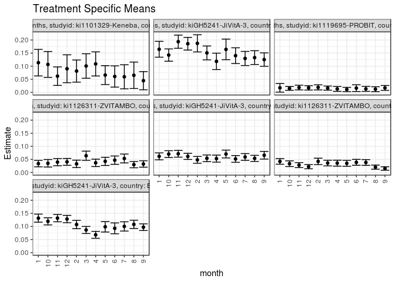

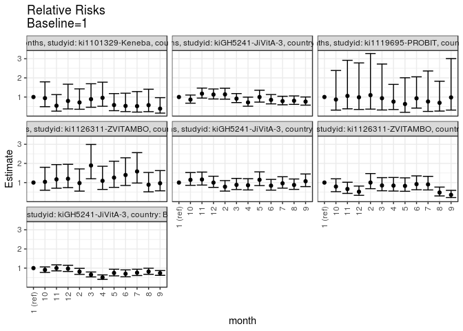

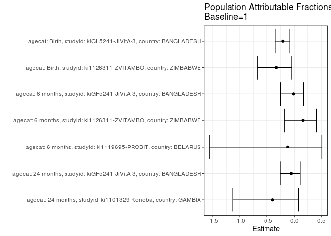

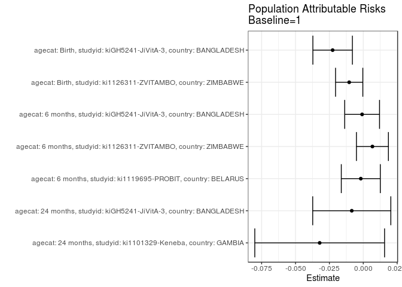

## Results Table

### Parameter: TSM

| agecat | studyid | country | intervention_level | baseline_level | estimate | ci_lower | ci_upper |
| --- | --- | --- | --- | --- | --- | --- | --- |
| Birth | ki1126311-ZVITAMBO | ZIMBABWE | 1 | NA | 0.0422535 | 0.0315182 | 0.0529888 |
| Birth | ki1126311-ZVITAMBO | ZIMBABWE | 2 | NA | 0.0422671 | 0.0300445 | 0.0544896 |
| Birth | ki1126311-ZVITAMBO | ZIMBABWE | 3 | NA | 0.0358392 | 0.0250670 | 0.0466114 |
| Birth | ki1126311-ZVITAMBO | ZIMBABWE | 4 | NA | 0.0355030 | 0.0241129 | 0.0468931 |
| Birth | ki1126311-ZVITAMBO | ZIMBABWE | 5 | NA | 0.0348606 | 0.0235141 | 0.0462070 |
| Birth | ki1126311-ZVITAMBO | ZIMBABWE | 6 | NA | 0.0387665 | 0.0275358 | 0.0499973 |
| Birth | ki1126311-ZVITAMBO | ZIMBABWE | 7 | NA | 0.0381679 | 0.0272307 | 0.0491051 |
| Birth | ki1126311-ZVITAMBO | ZIMBABWE | 8 | NA | 0.0202922 | 0.0124186 | 0.0281658 |
| Birth | ki1126311-ZVITAMBO | ZIMBABWE | 9 | NA | 0.0151286 | 0.0085484 | 0.0217088 |
| Birth | ki1126311-ZVITAMBO | ZIMBABWE | 10 | NA | 0.0334288 | 0.0225403 | 0.0443173 |
| Birth | ki1126311-ZVITAMBO | ZIMBABWE | 11 | NA | 0.0280702 | 0.0184817 | 0.0376587 |
| Birth | ki1126311-ZVITAMBO | ZIMBABWE | 12 | NA | 0.0220820 | 0.0139934 | 0.0301706 |
| Birth | kiGH5241-JiVitA-3 | BANGLADESH | 1 | NA | 0.1316288 | 0.1161609 | 0.1470967 |
| Birth | kiGH5241-JiVitA-3 | BANGLADESH | 2 | NA | 0.1072248 | 0.0913274 | 0.1231221 |
| Birth | kiGH5241-JiVitA-3 | BANGLADESH | 3 | NA | 0.0864078 | 0.0729427 | 0.0998728 |
| Birth | kiGH5241-JiVitA-3 | BANGLADESH | 4 | NA | 0.0678308 | 0.0546504 | 0.0810111 |
| Birth | kiGH5241-JiVitA-3 | BANGLADESH | 5 | NA | 0.0984361 | 0.0785934 | 0.1182787 |
| Birth | kiGH5241-JiVitA-3 | BANGLADESH | 6 | NA | 0.0927093 | 0.0719655 | 0.1134530 |
| Birth | kiGH5241-JiVitA-3 | BANGLADESH | 7 | NA | 0.1000000 | 0.0822809 | 0.1177191 |
| Birth | kiGH5241-JiVitA-3 | BANGLADESH | 8 | NA | 0.1078717 | 0.0920646 | 0.1236788 |
| Birth | kiGH5241-JiVitA-3 | BANGLADESH | 9 | NA | 0.0970446 | 0.0843008 | 0.1097883 |
| Birth | kiGH5241-JiVitA-3 | BANGLADESH | 10 | NA | 0.1194399 | 0.1057957 | 0.1330840 |
| Birth | kiGH5241-JiVitA-3 | BANGLADESH | 11 | NA | 0.1317486 | 0.1177266 | 0.1457705 |
| Birth | kiGH5241-JiVitA-3 | BANGLADESH | 12 | NA | 0.1281481 | 0.1140973 | 0.1421990 |
| 6 months | ki1119695-PROBIT | BELARUS | 1 | NA | 0.0172414 | 0.0007512 | 0.0337316 |
| 6 months | ki1119695-PROBIT | BELARUS | 2 | NA | 0.0189274 | 0.0091703 | 0.0286846 |
| 6 months | ki1119695-PROBIT | BELARUS | 3 | NA | 0.0161580 | 0.0082849 | 0.0240311 |
| 6 months | ki1119695-PROBIT | BELARUS | 4 | NA | 0.0130841 | 0.0037456 | 0.0224226 |
| 6 months | ki1119695-PROBIT | BELARUS | 5 | NA | 0.0109489 | 0.0027783 | 0.0191195 |
| 6 months | ki1119695-PROBIT | BELARUS | 6 | NA | 0.0160714 | 0.0032535 | 0.0288894 |

[output cut: 54 more lines]

### Parameter: E(Y)

| agecat | studyid | country | intervention_level | baseline_level | estimate | ci_lower | ci_upper |
| --- | --- | --- | --- | --- | --- | --- | --- |
| Birth | ki1126311-ZVITAMBO | ZIMBABWE | NA | NA | 0.0318559 | 0.0289336 | 0.0347781 |
| Birth | kiGH5241-JiVitA-3 | BANGLADESH | NA | NA | 0.1090180 | 0.1044666 | 0.1135695 |
| 6 months | ki1119695-PROBIT | BELARUS | NA | NA | 0.0154178 | 0.0100323 | 0.0208033 |
| 6 months | ki1126311-ZVITAMBO | ZIMBABWE | NA | NA | 0.0404891 | 0.0363397 | 0.0446385 |
| 6 months | kiGH5241-JiVitA-3 | BANGLADESH | NA | NA | 0.0606746 | 0.0568229 | 0.0645262 |
| 24 months | ki1101329-Keneba | GAMBIA | NA | NA | 0.0811594 | 0.0682689 | 0.0940499 |
| 24 months | kiGH5241-JiVitA-3 | BANGLADESH | NA | NA | 0.1560473 | 0.1472898 | 0.1648047 |

### Parameter: RR

| agecat | studyid | country | intervention_level | baseline_level | estimate | ci_lower | ci_upper |
| --- | --- | --- | --- | --- | --- | --- | --- |
| Birth | ki1126311-ZVITAMBO | ZIMBABWE | 1 | 1 | 1.0000000 | 1.0000000 | 1.0000000 |
| Birth | ki1126311-ZVITAMBO | ZIMBABWE | 2 | 1 | 1.0003202 | 0.6807147 | 1.4699852 |
| Birth | ki1126311-ZVITAMBO | ZIMBABWE | 3 | 1 | 0.8481935 | 0.5722313 | 1.2572401 |
| Birth | ki1126311-ZVITAMBO | ZIMBABWE | 4 | 1 | 0.8402367 | 0.5580474 | 1.2651215 |
| Birth | ki1126311-ZVITAMBO | ZIMBABWE | 5 | 1 | 0.8250332 | 0.5459466 | 1.2467883 |
| Birth | ki1126311-ZVITAMBO | ZIMBABWE | 6 | 1 | 0.9174743 | 0.6240906 | 1.3487770 |
| Birth | ki1126311-ZVITAMBO | ZIMBABWE | 7 | 1 | 0.9033079 | 0.6159067 | 1.3248194 |
| Birth | ki1126311-ZVITAMBO | ZIMBABWE | 8 | 1 | 0.4802489 | 0.3020261 | 0.7636394 |
| Birth | ki1126311-ZVITAMBO | ZIMBABWE | 9 | 1 | 0.3580435 | 0.2163584 | 0.5925127 |
| Birth | ki1126311-ZVITAMBO | ZIMBABWE | 10 | 1 | 0.7911493 | 0.5234251 | 1.1958105 |
| Birth | ki1126311-ZVITAMBO | ZIMBABWE | 11 | 1 | 0.6643275 | 0.4340058 | 1.0168782 |
| Birth | ki1126311-ZVITAMBO | ZIMBABWE | 12 | 1 | 0.5226078 | 0.3346363 | 0.8161665 |
| Birth | kiGH5241-JiVitA-3 | BANGLADESH | 1 | 1 | 1.0000000 | 1.0000000 | 1.0000000 |
| Birth | kiGH5241-JiVitA-3 | BANGLADESH | 2 | 1 | 0.8145997 | 0.6717145 | 0.9878790 |
| Birth | kiGH5241-JiVitA-3 | BANGLADESH | 3 | 1 | 0.6564504 | 0.5404977 | 0.7972784 |
| Birth | kiGH5241-JiVitA-3 | BANGLADESH | 4 | 1 | 0.5153186 | 0.4115897 | 0.6451893 |
| Birth | kiGH5241-JiVitA-3 | BANGLADESH | 5 | 1 | 0.7478308 | 0.5947039 | 0.9403854 |
| Birth | kiGH5241-JiVitA-3 | BANGLADESH | 6 | 1 | 0.7043237 | 0.5467040 | 0.9073865 |
| Birth | kiGH5241-JiVitA-3 | BANGLADESH | 7 | 1 | 0.7597122 | 0.6135526 | 0.9406899 |
| Birth | kiGH5241-JiVitA-3 | BANGLADESH | 8 | 1 | 0.8195147 | 0.6761919 | 0.9932155 |
| Birth | kiGH5241-JiVitA-3 | BANGLADESH | 9 | 1 | 0.7372593 | 0.6233007 | 0.8720532 |
| Birth | kiGH5241-JiVitA-3 | BANGLADESH | 10 | 1 | 0.9073993 | 0.7737910 | 1.0640773 |
| Birth | kiGH5241-JiVitA-3 | BANGLADESH | 11 | 1 | 1.0009102 | 0.8559643 | 1.1704006 |
| Birth | kiGH5241-JiVitA-3 | BANGLADESH | 12 | 1 | 0.9735572 | 0.8249064 | 1.1489953 |
| 6 months | ki1119695-PROBIT | BELARUS | 1 | 1 | 1.0000000 | 1.0000000 | 1.0000000 |
| 6 months | ki1119695-PROBIT | BELARUS | 2 | 1 | 1.0977918 | 0.3684107 | 3.2712047 |
| 6 months | ki1119695-PROBIT | BELARUS | 3 | 1 | 0.9371634 | 0.3226049 | 2.7224483 |
| 6 months | ki1119695-PROBIT | BELARUS | 4 | 1 | 0.7588785 | 0.3468165 | 1.6605224 |
| 6 months | ki1119695-PROBIT | BELARUS | 5 | 1 | 0.6350365 | 0.2010663 | 2.0056632 |
| 6 months | ki1119695-PROBIT | BELARUS | 6 | 1 | 0.9321429 | 0.4228843 | 2.0546761 |

[output cut: 54 more lines]

### Parameter: PAR

| agecat | studyid | country | intervention_level | baseline_level | estimate | ci_lower | ci_upper |
| --- | --- | --- | --- | --- | --- | --- | --- |
| Birth | ki1126311-ZVITAMBO | ZIMBABWE | 1 | NA | -0.0103977 | -0.0204662 | -0.0003291 |
| Birth | kiGH5241-JiVitA-3 | BANGLADESH | 1 | NA | -0.0226108 | -0.0371965 | -0.0080250 |
| 6 months | ki1119695-PROBIT | BELARUS | 1 | NA | -0.0018236 | -0.0162160 | 0.0125689 |
| 6 months | ki1126311-ZVITAMBO | ZIMBABWE | 1 | NA | 0.0067542 | -0.0050445 | 0.0185529 |
| 6 months | kiGH5241-JiVitA-3 | BANGLADESH | 1 | NA | -0.0008639 | -0.0137205 | 0.0119927 |
| 24 months | ki1101329-Keneba | GAMBIA | 1 | NA | -0.0321739 | -0.0800626 | 0.0157148 |
| 24 months | kiGH5241-JiVitA-3 | BANGLADESH | 1 | NA | -0.0084917 | -0.0373182 | 0.0203347 |

### Parameter: PAF

| agecat | studyid | country | intervention_level | baseline_level | estimate | ci_lower | ci_upper |
| --- | --- | --- | --- | --- | --- | --- | --- |
| Birth | ki1126311-ZVITAMBO | ZIMBABWE | 1 | NA | -0.3263973 | -0.6816549 | -0.0461895 |
| Birth | kiGH5241-JiVitA-3 | BANGLADESH | 1 | NA | -0.2074038 | -0.3487813 | -0.0808452 |
| 6 months | ki1119695-PROBIT | BELARUS | 1 | NA | -0.1182773 | -1.5569232 | 0.5109184 |
| 6 months | ki1126311-ZVITAMBO | ZIMBABWE | 1 | NA | 0.1668143 | -0.1813862 | 0.4123865 |
| 6 months | kiGH5241-JiVitA-3 | BANGLADESH | 1 | NA | -0.0142383 | -0.2499392 | 0.1770165 |
| 24 months | ki1101329-Keneba | GAMBIA | 1 | NA | -0.3964286 | -1.1268649 | 0.0831516 |
| 24 months | kiGH5241-JiVitA-3 | BANGLADESH | 1 | NA | -0.0544177 | -0.2562774 | 0.1150069 |